# Chemical_Kinetics_II

#### 14.

**Computer Lab – Chemical Kinetics 2**

**Goal**: The purpose of this lab is to compare two- and three-state models of protein folding kinetics using the steady-state approximation

**Introduction**

This exercise is based on the following paper:

> Teilum, K., Maki, K., Kragelund, B. B., Poulsen, F. M., & Roder, H. (2002). Early kinetic intermediate in the folding of acyl-CoA binding protein detected by fluorescence labeling and ultrarapid mixing. Proceedings of the National Academy of Sciences of the United States of America, 99(15), 9807–9812. doi:10.1073/pnas.152321499

```python
import IPython
url = 'https://www.rcsb.org/3d-view/2CB8/1'
iframe = '<iframe src=' + url + ' width=800 height=800></iframe>'
IPython.display.HTML(iframe)
```

[interactive chart not shown]

In this work, the folding kinetics of an 86-residue four helix-bundle protein called ACBP (acyl-CoA binding protein) was measured using time-resolved fluorescence spectroscopy (monitoring UV tryptophan fluorescence at 280 nm), after fast dilution from chemical denaturant (guanidinium hydrochloride, GuHCl) in a capillary mixer. The authors find that their data can be fit to the following kinetic model,

$$ U \underset{k_{IU}}{\stackrel{k_{UI}}{\rightleftharpoons}} I \underset{k_{NI}}{\stackrel{k_{IN}}{\rightleftharpoons}} N \tag{1}$$

where U is a highly fluorescent unfolded state, I is a partially folded intermediate, and N is the folded state.

**Procedure**

*Modeling the three-state mechanism*

Use SimBiology to construct a model of the three-state folding kinetics, using the following kinetic rate parameters determined by the authors at 299 K:

$$ U \underset{k_{IU}= 7000 s^{-1}}{\stackrel{k_{UI} = 11000 s^{-1}}{\rightleftharpoons}} I \underset{k_{NI} = 0.07 s^{-1}}{\stackrel{k_{IN} = 650 s^{-1}}{\rightleftharpoons}} N $$

Here is some experimental data that might be helpful in validating your model

| Time (ms) | Fluorescence intensity for the U state High concentration = more intensity |
| --- | --- |
| 0.2 | 1.1 |
| 0.4 | 1.0 |
| 0.6 | 0.98 |
| 0.8 | 0.96 |
| 1 | 0.91 |
| 2 | 0.6 |
| 20 | 0.33 |
| 40 | 0.32 |
| 60 | 0.31 |
| 80 | 0.29 |

Using initial concentrations of [U] = 10.0, [I] = 0.0, and [N] = 10.0, visualize the concentrations of each species over time. **Draw or print/plot the results below**.

**Using the results of your SimBiology model, estimate the populations of U and N at equilibrium.**

**Estimate from this the equilibrium constant *K* = [N<sub>equilibrium</sub>]/[U<sub>equilibrium</sub>] and the free energy of folding.**

**Modeling the two-state mechanism**

To find the steady-state approximation, we go through the following steps:

**1.** Write down an expression for *d*[I]/*dt* :

\begin{equation} \frac{d[I]}{dt} = -k_{IU}[I] - k_{IN}[I] + k_{UI}[U] + k_{NI}[I]\tag{1.1} \end{equation}

**2.** Solve $\frac{d[I]}{dt} = 0$ (i.e. steady-state conditions) to get $[I]$ as a function of $[U]$ and $[N]$ :

\begin{align} 0 &= -k_{IU}[I] - k_{IN}[I] + k_{UI}[U] + k_{NI}[N]\\ [I](k_{IU} + k_{IN}) &= k_{UI}[U] + k_{NI}[N]\\ [I] &= (k_{UI}[U] + k_{NI}[N])/(k_{IU} + k_{IN}) \end{align}

**3.** Next, we plug this expression for $[I]$ into the rate laws for $[U]$ and $[N]$:

\begin{align} \frac{d[U]}{dt} &= -k_{UI}[U] + k_{IU}[I]\\ &= -k_{UI}[U] + k_{IU} (k_{UI}[U] + k_{NI}[N])/(k_{IU} + k_{IN}) \tag{1.2}\\ \frac{d[N]}{dt} &= -k_{NI}[N] + k_{IN}[I]\\ &= -k_{NI}[N] + k_{IN} (k_{UI}[U] + k_{NI}[N])/(k_{IU} + k_{IN}) \tag{1.3} \end{align}

```python
import numpy as np
import pandas as pd
```

```python
def ODE_eqs(C, t, k):
    r"""See eqs 1.1, 1.2 and 1.3
    :math:`U \underset{k_{IU}}{\stackrel{k_{UI}}{\rightleftharpoons}} \
    I \underset{k_{NI}}{\stackrel{k_{IN}}{\rightleftharpoons}} N`

    Args:
        C(list): collection of concentrations for each species [L, R, LR, ...]
        t(float): iterate over some time-course
        k(list): collection of rate constants [kf1, kb1, kf2, ...]
    """

    U, I, N = C[0], C[1], C[2]
    kUI, kIU, kIN, kNI = k[0], k[1], k[2], k[3]
    dIdt = - kIU*I - kIN*I + kUI*U + kNI*I
    dUdt = - kUI*U + kIU*I
    dNdt = - kNI*N + kIN*I
    return [dUdt, dIdt, dNdt]



def ODE_eqs_SS(C, t, k):
    r"""See eqs 1.1, 1.2 and 1.3
    :math:`U \underset{k_{IU}}{\stackrel{k_{UI}}{\rightleftharpoons}} \
    I \underset{k_{NI}}{\stackrel{k_{IN}}{\rightleftharpoons}} N`

    Args:
        C(list): collection of concentrations for each species [L, R, LR, ...]
        t(float): iterate over some time-course
        k(list): collection of rate constants [kf1, kb1, kf2, ...]
    """

    U, I, N = C[0], C[1], C[2]
    kUI, kIU, kIN, kNI = k[0], k[1], k[2], k[3]
    dIdt = - kIU*I - kIN*I + kUI*U + kNI*I
    dUdt = - kUI*U + kIU*(kUI*U+kNI*N)/(kIU+kIN)
    dNdt = - kNI*N + kIN*(kUI*U+kNI*N)/kIU+kIN
    return [dUdt, dIdt, dNdt]



def simulate(steps, simulation_time, parameters, rate_eqs):
    """Method for integrating the ODEs with SciPy odeint
    https://docs.scipy.org/doc/scipy/reference/generated/scipy.integrate.odeint.html

    Args:
        steps(int): number of iterations
        simulation_time(int): duration of simulation (units: s)
        parameters(dict): {"species": ["L", "R", "LR"],\
                          "k": [kf1, kb1, kf2, kb2, ...],\  # rate constants
                          "InitConc": [L, R, P, ...]}       # initial concentrations (units: M)
        rate_eqs(function): method containing the ordinary differential equations
    Returns:
        Pandas DataFrame, plot
    """

    from scipy.integrate import odeint
    print(f"Number of species: {len(parameters['InitConc'])}")
    time = np.linspace(0, simulation_time, steps)
    C = odeint(rate_eqs, parameters["InitConc"], time, (parameters["k"],)).transpose()
    data = {"time": time, **{"%s"%s: C[i] for i,s in enumerate(parameters["species"])}}
    df = pd.DataFrame(data)
    plot = df.plot(x="time", y=parameters["species"], figsize=(10, 4),
                   xlim=(data["time"][0], data["time"][-1]))
    return df,plot


def dG(parameters, df):
    """Print ∆G = -RTln(K) for model and 'equilibrium' concentrations

    Args:
        parameters(dict): {"species": ["L", "R", "LR"],\
                          "k": [kf1, kb1, kf2, kb2, ...],\  # rate constants
                          "InitConc": [L, R, P, ...]}       # initial concentrations (units: M)
        df(DataFrame): pandas DataFrame of simulation
    """

    R, T = 8.314, 299 #units: Jmmol^-1K^-1 , units: K
    print("\nFrom equilibrium concentrations:")
    U = df["U"][df.index[-1]]
    N = df["N"][df.index[-1]]
    K = N/U
    dG = -R*T*np.log(K)
    print(f"K = {N: 0.3g}/{U: 0.3g} = {K: 0.3g}")
    print(f"∆G = -RTln(K) = {dG/1000: 0.3g} kJ mol^-1")
    print("\nFrom model parameters:")
    kUI = parameters["k"][0]
    kIU = parameters["k"][1]
    kIN = parameters["k"][2]
    kNI = parameters["k"][3]
    kf = kIN*(kUI/(kIU+kIN))
    kb = kNI*(kIU/(kIU+kIN))
    K = kf/kb
    dG = -R*T*np.log(K)
    print(f"k_forward = {kf: 0.3g} s^-1")
    print(f"k_backward = {kb: 0.3g} s^-1")
    print(f"K = {K: 0.3g}")
    print(f"∆G = -RTln(K) = {dG/1000: 0.3g} kJ mol^-1")

def get_subset(df, index):
    return pd.DataFrame(df.loc[index, df.columns])
```

```
Number of species: 3
```

|  | time | U | I | N |
| --- | --- | --- | --- | --- |
| 0 | 0.000000e+00 | 10.000000 | 0.000000 | 10.000000 |
| 1 | 9.000900e-07 | 9.901788 | 0.098183 | 10.000028 |
| 2 | 1.800180e-06 | 9.805154 | 0.194732 | 10.000113 |
| 3 | 2.700270e-06 | 9.710072 | 0.289672 | 10.000254 |
| 4 | 3.600360e-06 | 9.616517 | 0.383030 | 10.000451 |
| ... | ... | ... | ... | ... |
| 9995 | 8.996400e-03 | 0.119933 | 0.181757 | 19.688535 |
| 9996 | 8.997300e-03 | 0.119890 | 0.181693 | 19.688640 |
| 9997 | 8.998200e-03 | 0.119848 | 0.181629 | 19.688745 |
| 9998 | 8.999100e-03 | 0.119806 | 0.181565 | 19.688850 |
| 9999 | 9.000000e-03 | 0.119764 | 0.181501 | 19.688955 |

10000 rows × 4 columns

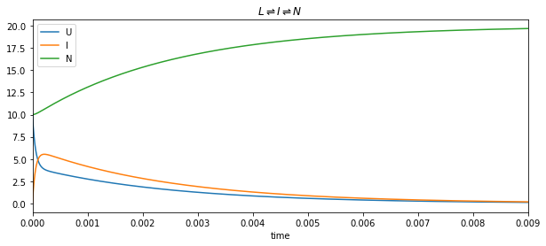

```python
# U = I = N
#[U] = 10.0, [I] = 0.0, and [N] = 10.0,
"""
k𝑈𝐼=11000𝑠−1, k𝐼𝑁=650𝑠−1
k𝐼𝑈=7000𝑠−1, k𝑁𝐼=0.07𝑠−1
"""
parameters = {"species": ["U", "I", "N", ],
             "InitConc": [10.0, 0.0, 10.0, ],
             #            [kf1, kb1, kf2, ...]
             "k":        [11000.0, 7000.0, 650.0, 0.07]}
df,plot = simulate(steps=10000, simulation_time=0.009,#simulation_time=0.005,
                   parameters=parameters, rate_eqs=ODE_eqs)
plot = plot.set_title(r"$L \rightleftharpoons I \rightleftharpoons N$")
fig = plot.get_figure()
#fig.savefig("figure.png")
df
```

```python
# Find where the first derivative is zero
#print(f'd[I]/dt = 0 @ t = {df["time"][df["I"][np.where(np.diff(df["I"]) <= 0.0)[0]].index[0]]: 0.3g} s')
#print(f'[I] = {df["I"][df["I"][np.where(np.diff(df["I"]) <= 0.0)[0]].index[0]]: 0.3g} M')
#print(f'[U] = {df["U"][df["I"][np.where(np.diff(df["I"]) <= 0.0)[0]].index[0]]: 0.3g} M')
#print(f'[N] = {df["N"][df["I"][np.where(np.diff(df["I"]) <= 0.0)[0]].index[0]]: 0.3g} M')
#sub = get_subset(df, index=range(0,800))
#sub.plot(x="time",figsize=(10, 4))
#sub
```

```
Number of species: 3
```

|  | time | U | I | N |
| --- | --- | --- | --- | --- |
| 0 | 0.000000e+00 | 10.000000 | 0.000000 | 10.000000 |
| 1 | 5.000500e-07 | 9.995328 | 0.054888 | 10.005431 |
| 2 | 1.000100e-06 | 9.990658 | 0.109540 | 10.010860 |
| 3 | 1.500150e-06 | 9.985990 | 0.163958 | 10.016286 |
| 4 | 2.000200e-06 | 9.981324 | 0.218143 | 10.021710 |
| ... | ... | ... | ... | ... |
| 9995 | 4.998000e-03 | 0.095161 | 0.155550 | 24.073931 |
| 9996 | 4.998500e-03 | 0.095118 | 0.155479 | 24.074304 |
| 9997 | 4.999000e-03 | 0.095074 | 0.155407 | 24.074677 |
| 9998 | 4.999500e-03 | 0.095030 | 0.155336 | 24.075049 |
| 9999 | 5.000000e-03 | 0.094987 | 0.155264 | 24.075422 |

10000 rows × 4 columns

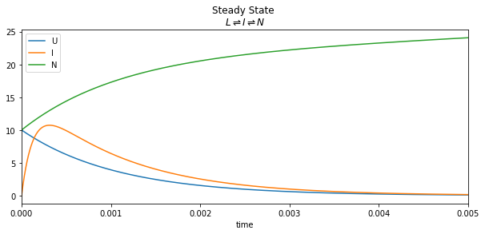

```python
# Stead State Approximation
parameters = {"species": ["U", "I", "N", ],
             "InitConc": [10.0, 0.0, 10.0, ],
             #            [kf1, kb1, kf2, ...]
             "k":        [11000.0, 7000.0, 650.0, 0.07]}
df,plot = simulate(steps=10000, simulation_time=0.005,
                   parameters=parameters, rate_eqs=ODE_eqs_SS)
plot = plot.set_title(r"""Steady State
$L \rightleftharpoons I \rightleftharpoons N$""")
fig = plot.get_figure()
#fig.savefig("figure.png")
df
```

**4.** Finally, to get rates for a two-state $U\rightleftharpoons N$ model of folding, consider that at equilibrium, $\frac{d[U]}{dt} = \frac{d[N]}{dt} = 0$. **Set the two expressions for $\frac{d[U]}{dt}$ and $\frac{d[N]}{dt}$ above to be equal to each other, and rearrange the equation to get it in the following form:**

$$k_{forward} [U] = k_{backward}[N]$$

**What are your computed values of for $k_{forward}$ and $k_{backward}$?** (Hint: They should be close to the values of $k_{IN}$ and $k_{NI}$, since $I \to N$ is the rate-limiting step.)

**Estimate from $k_{forward}$ and $k_{backward}$ the equilibrium constant ($K = k_{f}/k_{b}$) and free energy of folding.**

$$k_{forward} = k_{IN} \left(\frac{k_{UI}}{k_{IU} + k_{IN}} \right)$$$$k_{backward} = k_{NI} \left(\frac{k_{IU}}{k_{IU} + k_{IN}}\right)$$

**NOTE: it takes some simplification to get this**

**2-state mechanism**

$$K = \frac{k_{f}}{k_{b}} = \frac{[N]}{[U]} $$$$\Delta G = -RT ln(K)$$$$k_{forward} = k_{IN} \left(\frac{k_{UI}}{k_{IU} + k_{IN}} \right) = 650(11000/(7000+650)) = 935 s^{-1}$$$$k_{backward} = k_{NI} \left(\frac{k_{IU}}{k_{IU} + k_{IN}}\right) = 0.07(7000/(7000+650)) = 0.064 s^{-1}$$

```python
## Find where the first derivative is zero
#print(f'd[I]/dt = 0 @ t = {df["time"][df["I"][np.where(np.diff(df["I"]) <= 0.0)[0]].index[0]]: 0.3g} s')
#print(f'd[I]/dt = 0 @ [I] = {df["I"][df["I"][np.where(np.diff(df["I"]) <= 0.0)[0]].index[0]]: 0.3g} M')
#print(f'd[I]/dt = 0 @ [U] = {df["U"][df["I"][np.where(np.diff(df["I"]) <= 0.0)[0]].index[0]]: 0.3g} M')
#print(f'd[I]/dt = 0 @ [N] = {df["N"][df["I"][np.where(np.diff(df["I"]) <= 0.0)[0]].index[0]]: 0.3g} M')
```

```python
dG(parameters, df)
```

```
From equilibrium concentrations:
K =  24.1/ 0.095 =  253
∆G = -RTln(K) = -13.8 kJ mol^-1

From model parameters:
k_forward =  935 s^-1
k_backward =  0.0641 s^-1
K =  1.46e+04
∆G = -RTln(K) = -23.8 kJ mol^-1
```

```
Number of species: 3
```

|  | time | U | I | N |
| --- | --- | --- | --- | --- |
| 0 | 0.000000 | 10.000000 | 0.000000 | 10.000000 |
| 1 | 0.000004 | 9.962683 | 0.432566 | 10.043383 |
| 2 | 0.000008 | 9.925505 | 0.850480 | 10.086613 |
| 3 | 0.000012 | 9.888466 | 1.254190 | 10.129692 |
| 4 | 0.000016 | 9.851566 | 1.644131 | 10.172620 |
| ... | ... | ... | ... | ... |
| 9995 | 0.039984 | 0.003168 | 0.004547 | 46.923449 |
| 9996 | 0.039988 | 0.003168 | 0.004547 | 46.926050 |
| 9997 | 0.039992 | 0.003168 | 0.004548 | 46.928652 |
| 9998 | 0.039996 | 0.003169 | 0.004548 | 46.931253 |
| 9999 | 0.040000 | 0.003169 | 0.004548 | 46.933854 |

10000 rows × 4 columns

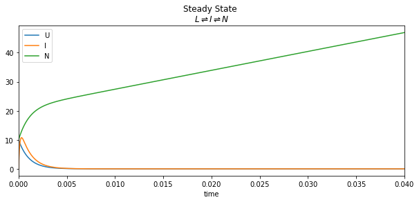

```python
# Stead State Approximation
parameters = {"species": ["U", "I", "N", ],
             "InitConc": [10.0, 0.0, 10.0, ],
             #            [kf1, kb1, kf2, ...]
             "k":        [11000.0, 7000.0, 650.0, 0.07]}
df,plot = simulate(steps=10000, simulation_time=0.04,#0.029,
                   parameters=parameters, rate_eqs=ODE_eqs_SS)
plot = plot.set_title(r"""Steady State
$L \rightleftharpoons I \rightleftharpoons N$""")
fig = plot.get_figure()
#fig.savefig("figure.png")
df
```

```python
dG(parameters, df)
```

```
From equilibrium concentrations:
K =  46.9/ 0.00317 =  1.48e+04
∆G = -RTln(K) = -23.9 kJ mol^-1

From model parameters:
k_forward =  935 s^-1
k_backward =  0.0641 s^-1
K =  1.46e+04
∆G = -RTln(K) = -23.8 kJ mol^-1
```